# Introduction to basic statistics with R

[figure not shown]

# Overview

This workshop will introduce you to basic statistics using R.

# Introduction

It is useful to begin with some concrete examples of statistical questions to motivate the material that we’ll cover in the workshop. This will also help confirm that your R environment is working. These data files come from the `fosdata` package, which you can optionally install to your computer in order to get access to all the associated metadata in the help files. I will show loading the data from the workshop website.

```
# optional: install the fosdata package using remotes::install_github
install.packages( "remotes" )
remotes::install_github( "speegled/fosdata" )
```

```r
# load the mice_pot and barnacles datasets
mice_pot = read.csv( url( "https://raw.githubusercontent.com/wes-brooks/basic-stats/main/data/mice_pot.csv" ))
barnacles = read.csv( url( "https://raw.githubusercontent.com/wes-brooks/basic-stats/main/data/barnacles.csv" ))
```

## `mice_pot` dataset

The `mice_pot` dataset contains data on an experiment that dosed four groups of mice with different levels of THC. There was a low, medium, and high dosage group, as well as a control group that got no THC. The mice were were then observed for a while and their total movement was quantified as a percentage of the baseline group mean. Some statistical questions that might arise here are: were there differences in the typical amount of movement between mice of different groups? What was the average amount of movement by mice in the medium dose group?

Both of these questions can be approached in ways that relate to the particular sample, which is kind of interesting descriptions of the data. For instance, if you install the `dplyr` package in your R environment, we can make those calculations right now.

```r
with( mice_pot, by(percent_of_act, group, mean))
```

```
## group: 0.3
## [1] 97.3225
## ------------------------------------------------------------
## group: 1
## [1] 99.05235
## ------------------------------------------------------------
## group: 3
## [1] 70.66787
## ------------------------------------------------------------
## group: VEH
## [1] 100
```

Because we don’t see we don’t see data from mice that weren’t part of the study, we rely on statistical **inference** to reach conclusions about the population. How is that possible? Well, some theorems from **mathematical statistics** can tell us about the **distribution** of the sample, relative to the population

## `barnacles` dataset

This dataset was collected by counting the barnacles in 88 grid squares on the Flower Garden Banks coral reef in the Gulf of Mexico. The counts were normalized to barnacles per square meter. Some questions that you might approach with statistical methods are, what is the average number of barnacles per square meter, and is it greater than 300?

```r
mean( barnacles$per_m )
```

```
## [1] 332.0186
```

From that calculation, we see that the mean is 332 barnacles per square meter, which is greater than 300. But again, the first calculation has told us only about the mean of the particular locations that were sampled. Wouldn’t it be better to answer the questions by reference to the number of barnaces per square meter of reef, rather than square meter of measurement? Here, the **population** is then entire area of the Flower Garden Banks reef. Again, we will be able to answer the questions relative to the entire reef by working out the sample mean’s distribution, relative to the population.

## Sample and population

I’ve made reference to samples and populations, and they are fundamental concepts in statistics. A sample is a pretty easy thing to understand - it is the data, the hard numbers that go into your calculations. The population is trickier. It’s the units to which you are able to generalize your conclusions.

For the barnacle data, in order for the population to be the entire Flower Garden Banks reef, the sample must have been carefully selected to ensure it was representative of the entire reef (for instance, randomly sampling locations so that any location on the reef might have been selected).

For the mice on THC, the population is all the mice that might have been selected for use in the experiment. How big that population is depends on how the mice were selected for the experiment. Randomly selecting the experimental units from a group is a common way of ensuring that the results can generalize to that whole group.

A non-random sample tends to mean that the population to which you can generalize is quite limited. What sort of population do you think we could generalize about if we recorded the age of everyone in this workshop?

# Probability distributions, quantiles, and densities

Probability distributions are functions that divvy up probability among the possible outcomes of a random variable. Each distribution has some important features, like its density and quantile functions.

## The Normal distribution

The Normal distribution plays a very special role in statistics, which we will come to. For now, let’s introduce the distribution. I’ve pictured here the density of a standard normal distribution.

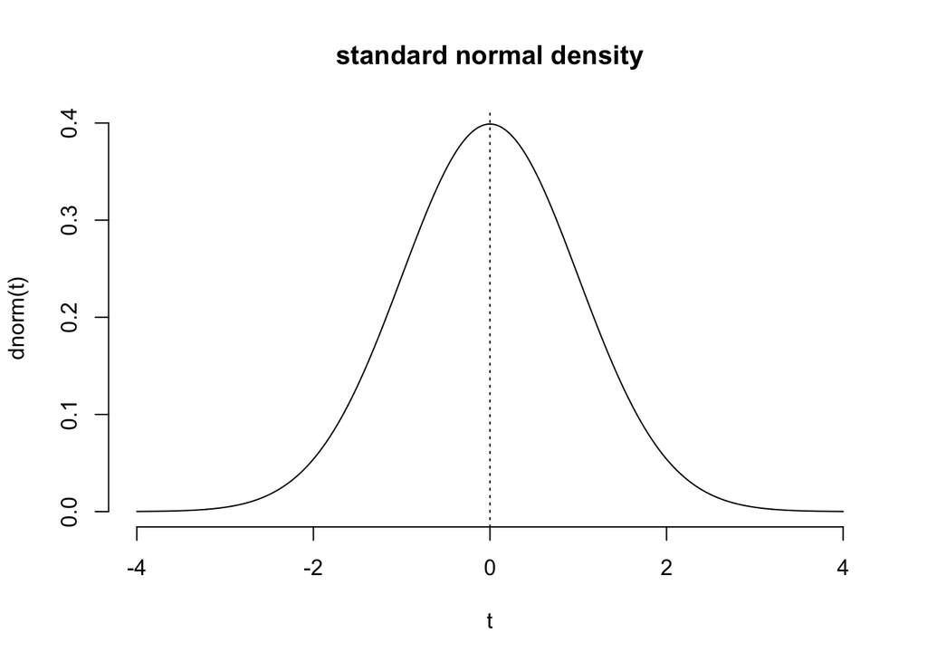

```r
# draw the standard normal distribution function, with some annotations
t = seq(-4, 4, length.out=1001)
plot( x=t, y=dnorm(t), bty='n', type='line', main="standard normal density")
abline(v=0, lty=3)
```

The probability density is called that because if you select a sample from the distribution, most of the numbers in your sample will be from the part of the curve with the greatest density. The Normal distribution, like any named distribution, represents a population from which samples can be taken. Let’s try it:

```r
# sample 20 numbers from a standard normal distribution:
x = rnorm(20)

# observe your sample:
print( round(x, 2) )
```

```
##  [1] -1.20  0.58 -0.23  0.82 -0.39  0.21 -0.43  1.59 -0.94 -0.88  0.55 -0.57
## [13] -0.02  0.69 -0.39 -0.72  0.36 -0.08 -1.19  0.94
```

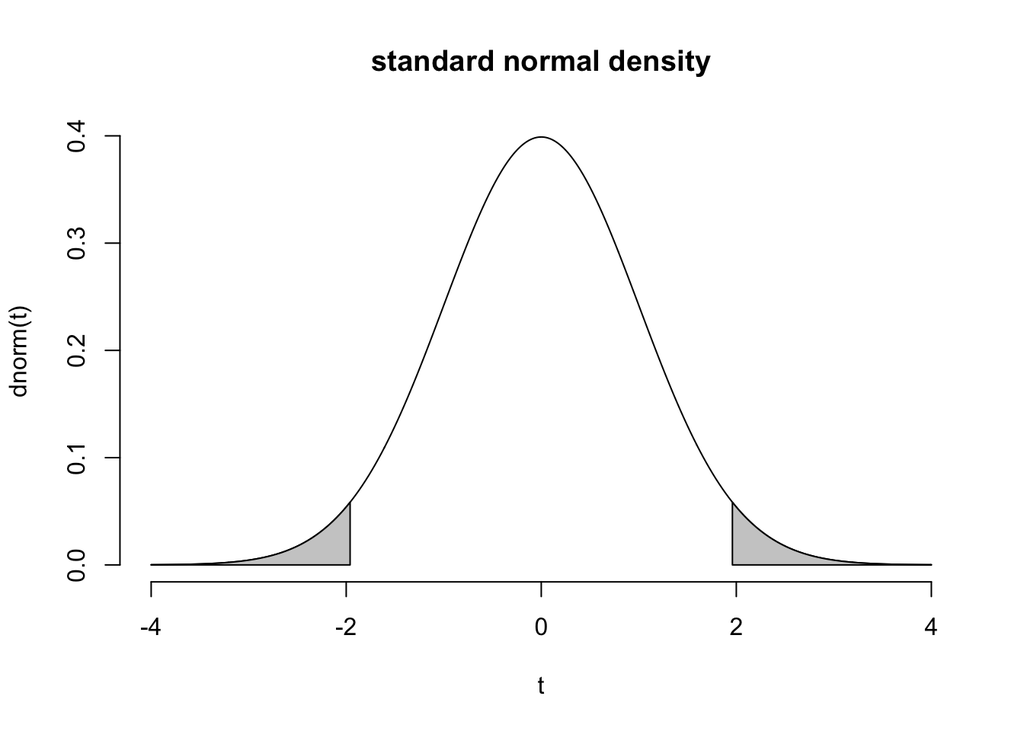

```r
# plot the standard normal density function with some annotations
plot( x=t, y=dnorm(t), bty='n', type='l', main="standard normal density")

# annotate the density function with the 5% probability mass tails
polygon(x=c(t[t<=qnorm(0.025)], qnorm(0.025), min(t)), y=c(dnorm(t[t<=qnorm(0.025)]), 0, 0), col=grey(0.8))

polygon(x=c(t[t>=qnorm(0.975)], max(t), qnorm(0.975)), y=c(dnorm(t[t>=qnorm(0.975)]), 0, 0), col=grey(0.8))
```

### Histograms and subsamples

While the density curve represents the standard Normal population, your data’s histogram represents your sample:

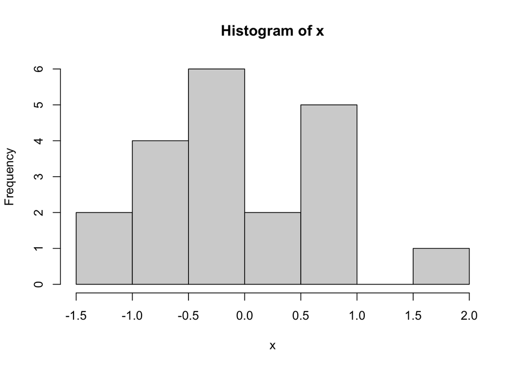

```r
# show the histogram of x
hist(x)
```

It might not look particularly like the Normal density, but that’s because it’s representing a particular sample, not the population. The curve might be more recognizable if the number of samples was greater.

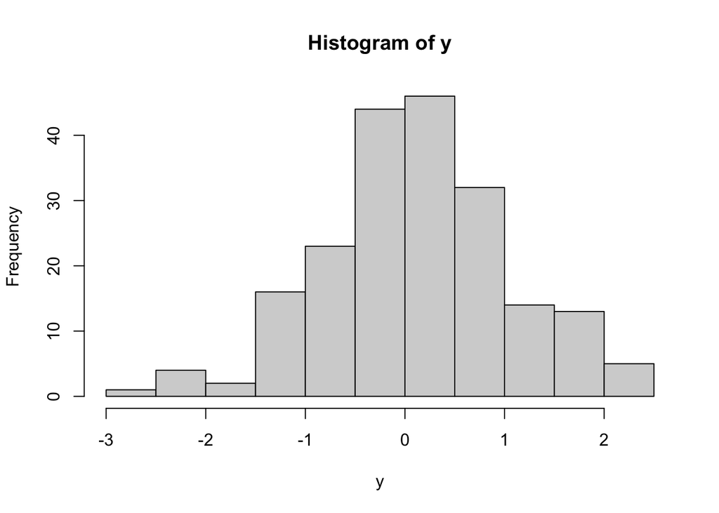

```r
# sample 200 numbers from a standard normal
y = rnorm( 200 )

# show the histogram of y
hist( y )
```

Now, while I’ve said that the histogram represents a sample rather than a population, that line can be blurred. You can **subsample** from your sample, using the `sample` function. There are some situations when you’re not working with a named distribution, but need to take samples from a list. This is how to do that.

```r
# take a sample of 20 numbers from x (without replacement)
x2 = sample( x, 20 )

# take a sample of 20 numbers from x (with replacement)
x3 = sample( x, 20, replace=TRUE )

# calculate the means of x, x2, and x3
mean( x )
```

```
## [1] -0.06447022
```

```r
mean( x2 )
```

```
## [1] -0.06447022
```

```r
mean( x3 )
```

```
## [1] 0.1833635
```

## Random variables and calculations:

A random variable is our name for some quantity that follows a random distribution. Examples:

```r
# X is a random variable, it follows the standard normal distribution
X = rnorm(1)

# Once we have "realized" a value of X, it is data and no longer random.
X
```

```
## [1] 0.5086344
```

### Mean and median

There are a few kinds of average that are commonly used in practical settings and we will use two of them extensively. The mean is the average you’re probably used to, calculated by summing up the values and then dividing by the number of values. The median is the midpoint of the data - it’s the number you arrive at if you write down all the values in order and then find the halfway point. There are special R functions for both of these.

```r
# calculate the mean and median of x. They aren't exactly zero in the sample.
mean(x)
```

```
## [1] -0.06447022
```

```r
median(x)
```

```
## [1] -0.1528678
```

### Expectation

Expectation is the mean of a population. So, a random variable has an expectation but data has a mean. There’s no R function to calculate an expectation because R expects to be working on data rather than on a population. If you think of R as a calculator, you can calculate the mean of any numbers that you can type into the calculator, but when the object is this abstract thing we call a distribution, the calculator can’t proceed.

Remember earlier, when we decided to treat a sample as a population and then take samples from it? Then the mean of the original sample becomes the expectation of all the subsamples:

```r
# subsample x 50 times with replacement, and store the mean of each
subx_mean = numeric( 50 )
for (i in 1:50) {
  subx_mean[[ i ]] = mean( sample(x, replace=TRUE) )
}

# print the results and the mean of the means
print( round( subx_mean, 2 ) )
```

```
##  [1]  0.19  0.09  0.15 -0.05  0.07  0.01 -0.06 -0.27  0.30 -0.28  0.01  0.01
## [13]  0.02  0.00 -0.25  0.02  0.10 -0.15 -0.10 -0.11 -0.12 -0.06 -0.08  0.01
## [25] -0.24 -0.17 -0.25  0.15 -0.10  0.06 -0.01 -0.24 -0.13 -0.06  0.10 -0.16
## [37] -0.08 -0.32 -0.11  0.13  0.06  0.07 -0.03  0.01 -0.04  0.19  0.25 -0.06
## [49] -0.06  0.08
```

```r
mean( subx_mean )
```

```
## [1] -0.02991768
```

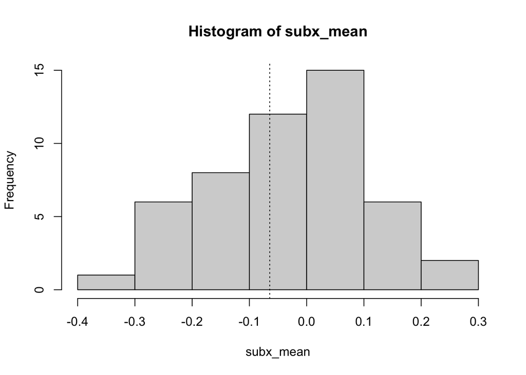

```r
# shoe the histogram of sample means, with an annotation at the expectation
hist( subx_mean )
abline( v=mean(x), lty=3 )
```

You might have noticed that I didn’t specify the `size` argument for the `sample()` function that time. By default, `sample()` will take a subsample of equal size to the input data. You can see from the above histogram that sample means are clustering around the population expectation, even though they don’t match exactly.

Denote the expectation of the random variable $X$ by $E(X)$. Typically, statisticians use the Greek letter $\mu$ to mean the expectation of a Normal random variable.

### Standard deviation and variance

The standard deviation comes about because of the need for a calculation that measures how far a typical sample is from the mean. The direct approach would be to calculate the average distance from the mean, but it turns out that this is always exactly zero. So instead, we’ve settled on the standard of calculating the average squared distance from the mean (almost). Here is the formula for the sample standard deviation, which we write as $s$ for a particular sample or $S$ for a random variable:

$$s = \text{sd}(x) = \sqrt{ \frac{\sum_{i=1}^n (x_i - \bar{x})^2}{n-1} }$$

The `n-1` in the denominator is used in calculating the standard deviation of a sample. For the population standard deviation the denomipnator would be `n`, but you will rarely calculate a population standard deviation. In either case, the square of the standard deviation is called **variance**:

$$\text{sd}(x) = \sqrt{ \text{var}(x) }$$

In R, you calculate the standard deviation with the `sd()` function. Let’s calculate some standard deviations and variances:

```r
# calculate the standard deviation of the barnacles per unit area
sd( barnacles$per_m )
```

```
## [1] 273.2828
```

```r
# calculate the variance of the body motion for mice who got the metium dose of THC:
var( mice_pot$percent_of_act[ mice_pot$group==1 ] )
```

```
## [1] 689.4729
```

For a Normal distribution, statisticians typically denote the population variance by the Greek letter $\sigma^2$. In sum, then, a Normal distribution is characterized by its mean and variance parameters, and statisticians usually abbreviate the Normal distribution that has mean $\mu$ and variance $\sigma^2$ by N($\mu$, $\sigma^2$). The **standard Normal** distribution that I’ve referred to is the N(0, 1) distribution, and you will typically use Z to denote a random variable with that distribution. Lets observe a few Normal distributions by changing the `mean` and `sd` arguments to `dnorm()`:

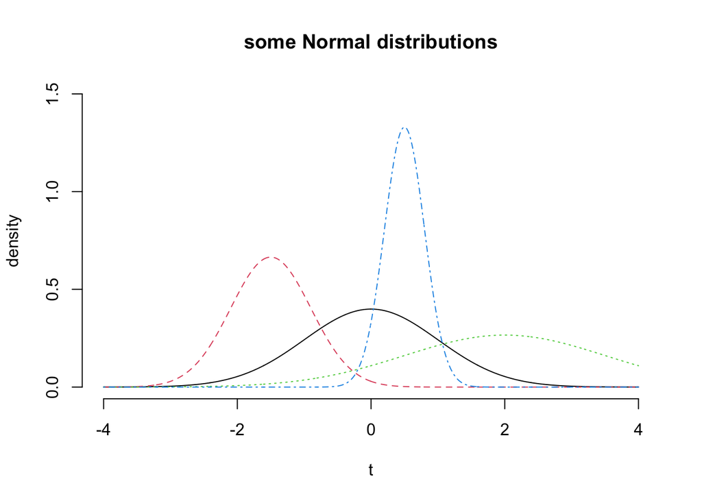

```r
# plot several Normal distributions with different means and sds:
yy = c(0, 1.5)
plot(x=t, y=dnorm(t, mean=0, sd=1), bty='n', type='l', main="some Normal distributions", ylab='density', ylim=yy)
par( new=TRUE )
plot(x=t, y=dnorm(t, mean=-1.5, sd=0.6), bty='n', type='l', xaxt='n', yaxt='n', xlab='', ylab='', lty=2, ylim=yy, col=2)
par( new=TRUE )
plot(x=t, y=dnorm(t, mean=02, sd=1.5), bty='n', type='l', xaxt='n', yaxt='n', xlab='', ylab='', lty=3, ylim=yy, col=3)
par( new=TRUE )
plot(x=t, y=dnorm(t, mean=0.5, sd=0.3), bty='n', type='l', xaxt='n', yaxt='n', xlab='', ylab='', lty=4, ylim=yy, col=4)
```

The basic shape persists, but the location and width change.

## Density, sampling, quantile, and distribution functions

All of R’s built-in distributions are characterized by four functions, with a consistent pattern in their naming:

- Density function begins with d (`dnorm()`)
- Sampling function begins with r (`rnorm()`)
- Quantile function begins with q (`qnorm()`)
- Distribution function begins with p (`pnorm()`)

Of these, I’ve already demonstrated `dnorm()` and `rnorm()`.

### Quantile function

```r
# demonstrate quantiles of the standard normal distribution
qnorm(0.95)
```

```
## [1] 1.644854
```

```r
qnorm(0.5)
```

```
## [1] 0
```

```r
# if you want an interval that contains the random variable 95% of the time, you may divide the remaining 5% in half, so the interval is in the center:
(1 - 0.95) / 2
```

```
## [1] 0.025
```

```r
qnorm(0.025)
```

```
## [1] -1.959964
```

```r
qnorm(0.975)
```

```
## [1] 1.959964
```

Thus, we can construct an **interval** from -1.96 to 1.96 that contains 95% of samples from N(0, 1).

If you’re working with a vector of numbers instead of a named distribution, then the quantiles are calculated by the `quantile()` function:

```r
# calculate the 0.025 and 0.975 quantiles of y
# specify the vector first, then the quantiles:
quantile(y, 0.025)
```

```
##      2.5%
## -1.830212
```

```r
quantile(y, 0.975)
```

```
##    97.5%
## 1.956817
```

```r
# get both quantiles in one line:
quantile(y, c(0.025, 0.975))
```

```
##      2.5%     97.5%
## -1.830212  1.956817
```

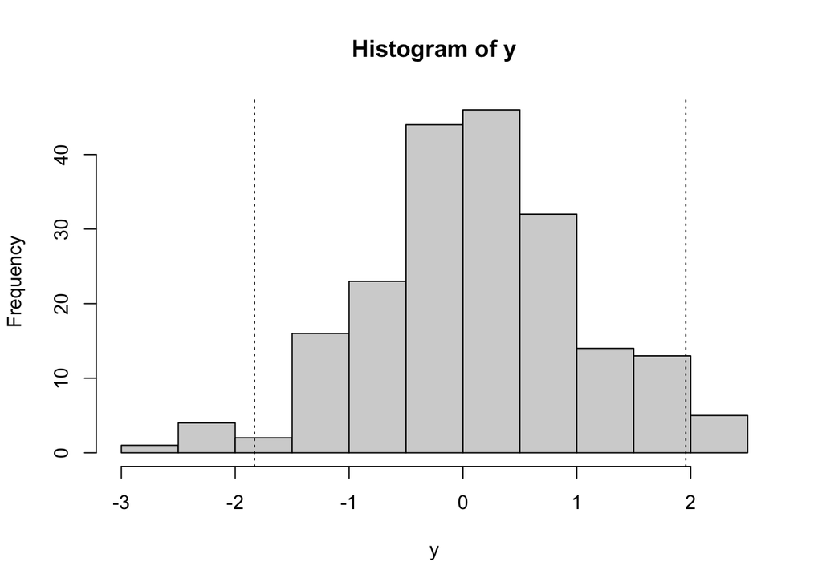

```r
# put the quantiles on the histogram
hist(y)
abline( v=quantile(y, c(0.025, 0.975)), lty=3 )
```

### Distribution function

The distribution function is the inverse of the quantile function. It calculates the probability that a random variable is less than or equal to some number. That is, $F_Z(t) = Pr(Z \le t)$. In an introductory statistics class, you’d typically spend a lot of time using paper tables to get comfortable going between the quantile and distribution functions. We can just do the calculations in R:

```r
# Demonstrate the standard normal distribution function:
pnorm(0)
```

```
## [1] 0.5
```

```r
pnorm(-1)
```

```
## [1] 0.1586553
```

```r
pnorm(1)
```

```
## [1] 0.8413447
```

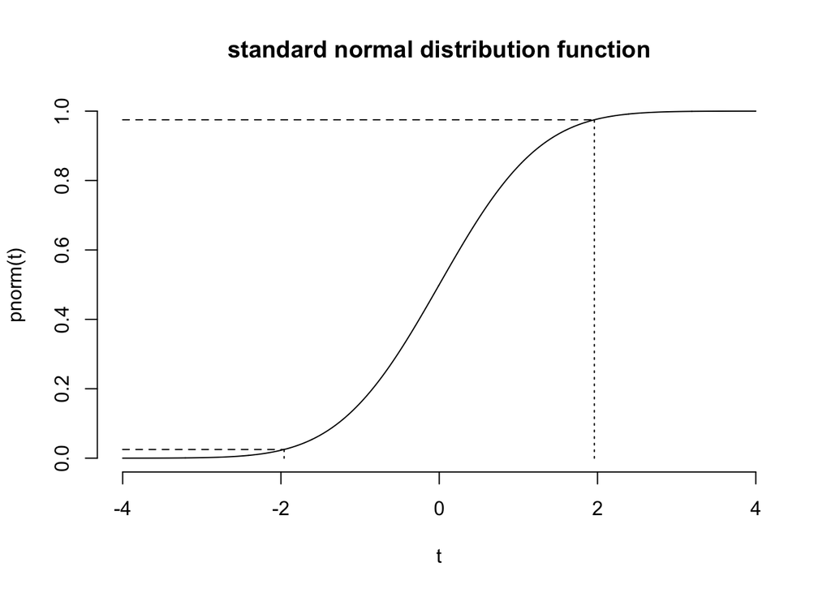

```r
# draw the standard normal distribution function, with some annotations
t = seq(-4, 4, length.out=1001)
plot( x=t, y=pnorm(t), bty='n', type='line', main="standard normal distribution function")
# annotate the plot with lines indicating the quantiles for a 95% probability interval
lines(x=c(min(t), qnorm(0.025)), y=rep(0.025, 2), lty=2)
lines(x=c(min(t), qnorm(0.975)), y=rep(0.975, 2), lty=2)

lines(x=rep(qnorm(0.025), 2), y=c(0, 0.025), lty=3)
lines(x=rep(qnorm(0.975), 2), y=c(0, 0.975), lty=3)
```

If you’re working on a vector of numbers rather than a named distribution, then you can use the `mean()` function to calculate what proportion are less than some value:

```r
# what proportion of the y sample is less than or equal to -2? What proportion is greater than 2?
mean( y <= -2 )
```

```
## [1] 0.025
```

```r
1 - mean( y<= 2 )
```

```
## [1] 0.025
```

### Other distributions

I have focused on the Normal distribution, but there are many others! You can take a little time to generate samples or quantiles or probabilities from some other distributions, like Poisson (`rpois()`, `qpois()`, etc.), binomial (`rbinom()`, `qbinom()`, etc), or t (`pt()`, `rt()`, etc). Alternatively, try answering some questions:

1. What is the probability that a sample from the N($1$, $3^2$) distribution is less than 0?
2. For the sample `y`, what is an interval that contains 80% of the values?

# Mathematical statistics

Now, let’s look at some of the math that allows us to use manipulate random variables in order to reason about their distributions. Beginning with some important identities that are used constantly when doing algebra with random variables. In particular, we will see how these identities relate to the mean. That’s because the mean has some special properties: you’ve seen how we can calculate intervals based on known distributions that contain samples with a specified frequency. But we need to know the distribution. It turns out that the distribution of the sample mean approaches the Normal distribution as the sample size increases, for almost any independent data. That allows us to create intervals and reason about the distribution of real data, even though the data’s distribution is unknown.

## Identities

The following hold for random variables $X_1, X_2, \dots$ that are independent:

- $E(aX_1) = aE(X_1)$
- $E(X_1 + X_2) = E(X_1) + E(X_2)$
- $var(aX) = a^2 var(X_1)$
- $var(X_1 + X_2) = var(X_1) + var(X_2)$

In the case of calculating the mean, $a$ is $1/n$. So if the $X_1, X_2, \dots$ all share the same mean $\mu$ and the same variance $\sigma^2$, then the expectation identities say that the expectation of the mean is
$$E[ \frac{1}{n} (X_1 + X_2 + \cdots + X_n) ] = \frac{1}{n} [ E(X_1) + E(X_2) + \cdots + E(X_n) ] \\ = \frac{1}{n} [n \times \mu ] \\
=\mu$$

And the variance identities say that the variance of the mean is
$$var[ \frac{1}{n} (X_1 + X_2 + \cdots + X_n) ] = \frac{1}{n^2} [ var(X_1) +var(X_2) + \cdots + var(X_n) ] \\
= \frac{1}{n^2} [n \times \sigma^2 ] \\
=\sigma^2 / n$$

So the mean of a sample of independent random variables has the same expectation as the population but its variance is much smaller. As a result, increasing sample size leads to greater precision in estimating the population mean. Let’s take a look at some examples:

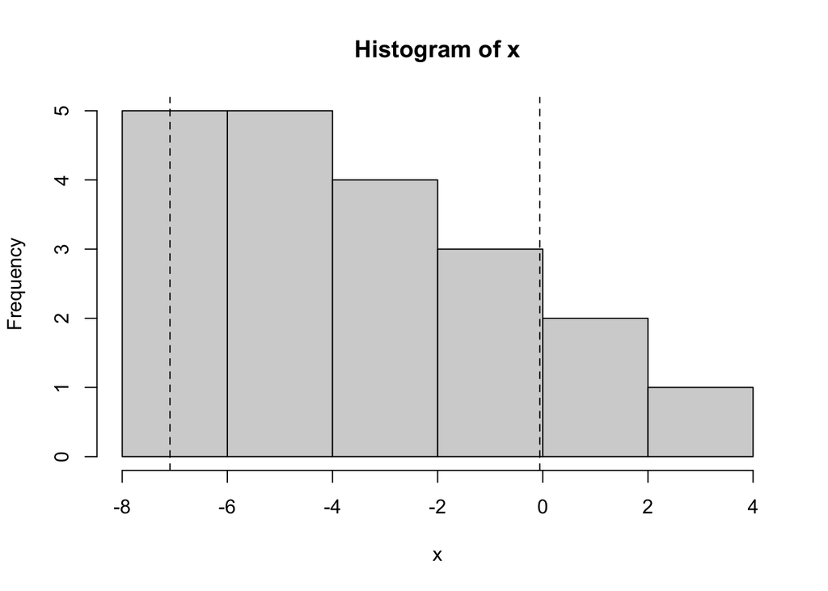

```r
# create a random variable X with mean -3 and standard deviation 3
X = function(n=20, mean=-3, sd=3) { rnorm(n, mean=mean, sd=sd) }

# show the histogram of some samples of X as well as the 0.12 and 0.88 quantiles:
x = X()
hist( x )
abline( v=quantile( x, c(0.12, 0.88) ), lty=2 )
```

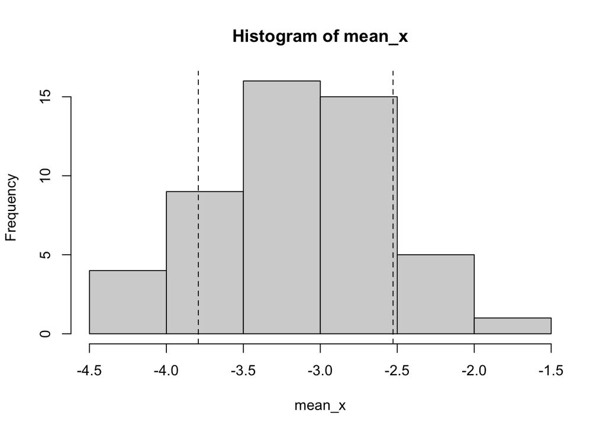

```r
# generate 50 samples of X and calculate their means:
mean_x = numeric( 50 )
for (i in 1:50) {
  mean_x[[ i ]] = mean( X() )
}

# plot the histogram of mean_x as well as the 0.12 and 0.88 quantiles
hist( mean_x )
abline( v=quantile( mean_x, c(0.12, 0.88) ), lty=2 )
```

## Law of large numbers

The law of large numbers says that if the individual measurements are independent, then the mean of a sample tends toward the mean of the population as the sample size gets larger. This is what we’d expect, since we showed the rate at which the variance of the sample mean gets smaller is $1/n$.

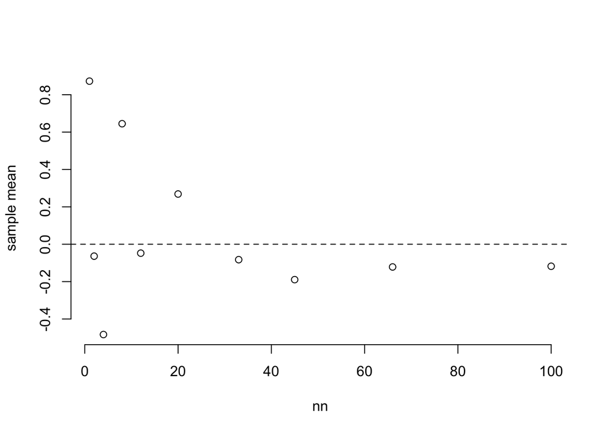

```r
nn = c(1, 2, 4, 8, 12, 20, 33, 45, 66, 100)
means = sapply( nn, function(n) mean( rnorm(n) ) )
plot(nn, means, bty='n', ylab = "sample mean")
abline(h=0, lty=2)
```

## Central limit theorem

The most important mathematical result in statistics, the Central Limit Theorem says that if you take (almost) any sample of random numbers and calculate its mean, the distribution of the mean tends toward a normal distribution. We illustrate the “tending toward” with an arrow and it indicates that the distribution of a sample mean is only *approximately* Normal. But if the original samples were from a Normal distribution then the sample mean has an *exactly* Normal distribution. From here, I’ll start writing the mean of a random variable $X$ as $\bar{X}$ and the mean of a sample $x$ as $\bar{x}$.

$$\bar{X} \rightarrow N(\mu, \frac{\sigma^2}{n})$$
And because of the identities we learned before, you can write this as
$$\frac{\bar{X} - \mu}{\sigma/\sqrt{n}} \rightarrow N(0, 1)$$

### But isn’t $\sigma$ unknown, too?

I’ve presented calculations that use the parameter $\sigma$. But in reality, $\sigma$ is just as unknown as $\mu$. Is it safe to replace $\sigma$ in the calculations by the standard deviation that we calculate from the sample using the `sd()` function? Not quite. If the $S$, the sample standard deviation (this is what you get from R’s `sd()` function) is used for $\sigma$ in the CLT, then you need to include the uncertainty of estimating $\sigma$ by $S$ in the uncertainty of the distribution. As a result, the distribution will be slightly less clustered at the central point and have “heavy tails”. This distribution is called the “t-distribution”, and its discovery was a triumph of early modern statistics.

$$\frac{\bar{X} - \mu}{S/\sqrt{n}} \rightarrow t_{n-1}$$

Here the $n-1$ subscript denotes the “degrees of freedom” of the t-distribution.

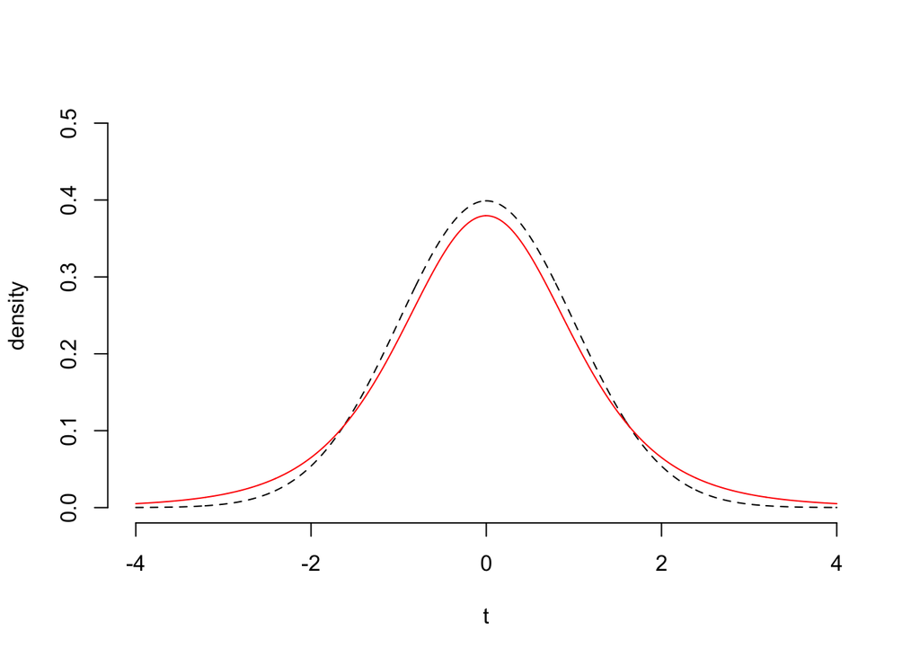

```r
# plot the densities of a standard normal distribution, and of a t-distribution with five degrees of freedom:
t = seq(-4, 4, length.out=1001)

plot( x=t, y=dnorm(t), ylim=c(0, 0.5), bty='n', lty=2, type='l', ylab="density" )
par( new=TRUE )
plot( x=t, y=dt(t, df=5), ylim=c(0, 0.5), xaxt='n', yaxt='n', xlab='', ylab='', bty='n', col='red', type='l' )
```

Once again, if the original samples were from a Normal distribution, then the distribution of the mean is exactly a $t$ distribution, but otherwie the $t$ distribution is an approximation that gets better as the sample size increases.

What’s more important than memorizing the precise formula is to remember that for (almost) any data where the samples are independent, the mean comes from some distribution that is more and more like the Normal distribution as the sample size increases. Let’s take a look at an example using the uniform distribution.

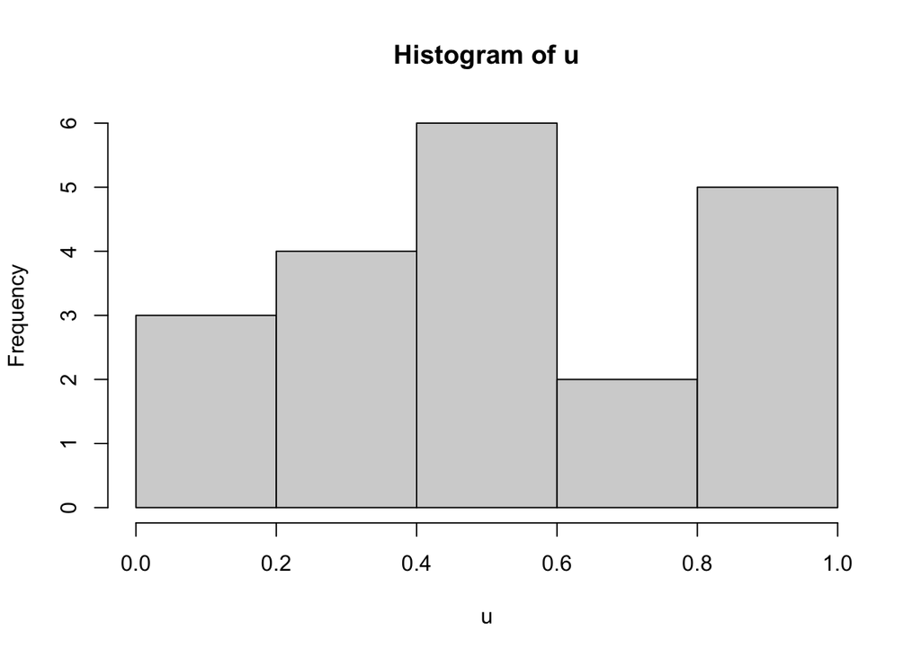

```r
# generate 20 samples from a uniform distribution and plot their histogram
N = 20
u = runif( N )
hist( u )
```

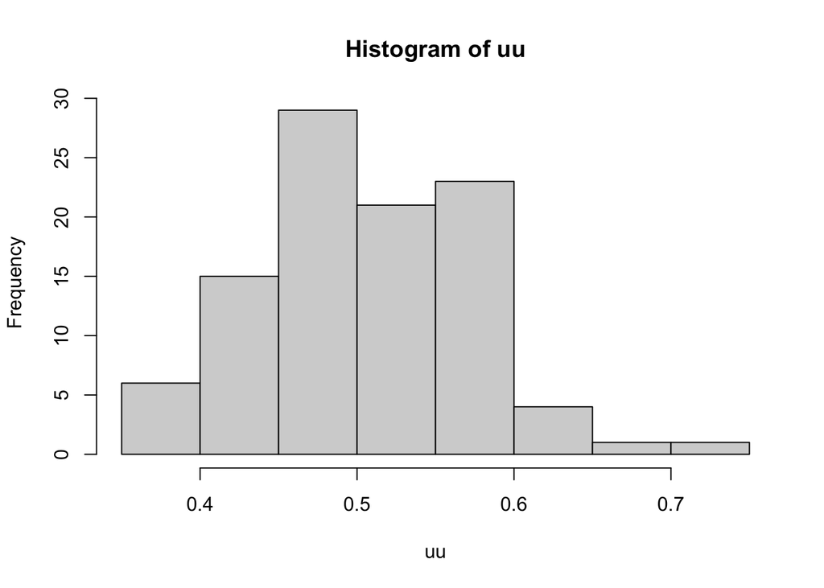

```r
# generate 100 repeated samples of the same size, calculate the mean of each one, and plot the histogram of the means.
B = 100
uu = numeric( B )
for ( i in 1:B ) {
  uu[[i]] = mean( runif(N) )
}

hist(uu)
```

```r
# what happens as B and N get larger and smaller? Do they play different roles?
```

## Events and intervals

Answering realistic statistical questions is often a matter of evaluating the probability of some event.

Given a t-distribution with eight degrees of freedom, the probability of sampling a number randomly from the distribution which is less than -1 is found from the distribution function:

```r
pt(-1, df=8)
```

```
## [1] 0.1732968
```

For that same distribution, if you want to know the value which is exceeded by 12% of samples, then you would use the quantile function:

```r
qt( 1 - 0.12, df=8 )
```

```
## [1] 1.26934
```

Again using the same distribution, you can evaluate the interval where 90% of samples are within the interval.

```r
qt( c(0.05, 0.95), df=8 )
```

```
## [1] -1.859548  1.859548
```

But if that $t_8$ random variable is the result of a calculation like $\frac{\bar{X} - \mu}{S/\sqrt{n}}$, then the event that it is in the interval (-1.86, 1.86) is the event

$$-1.86 < \frac{\bar{X} - \mu}{S/\sqrt{n}} \le 1.86$$

Here, $\bar{X}$ and $S$ are random, while $n$ is the known sample size and $\mu$ is the unknown but fixed paramter that we want to put bounds around. Just rearranging terms we can get:

$$\bar{X} - 1.86 \times S / \sqrt{n} \le \mu < \bar{X} + 1.86 \times S / \sqrt{n}$$
since this event occurs 90% of the time, we call the interval a 90% confidence interval. To change the confidence level, you would evaluate different quantiles of the t-distribution. If the degrees of freedom are not eight, then you would use the correct number for your data.

### Questions to ponder

- Can you see a way to make the confidence interval smaller other than changing the confidence level? Why would that be helpful?
- In the formula for a confidence interval, what is random and what is fixed? What would change if you collected new data by repeating the experiment? Does this suggest something about what the 90% means for our 90% confidence interval?

# Inference

Inference means making statements about the population based on a sample. In one simple case, inference can mean using a sample to estimate the mean of the population from which it arose. Since the law of large numbers says that the sample mean tends to the population mean, we’ll use the sample mean to approximate the population mean. You’ve already seen this in the plots where I showed the sample mean getting closer to the population mean as the sample size increased.

## Revisiting the standard normal distribution:

The distribution, density, and quantile functions are all about the population. When you’re working with data, the graphs won’t be as clean. When you’re using methods that depend upon the data being approximately normal, you’ll have to check some diagnostics. One simple but effective approach is to look at the histogram and QQ plot, and judge whether there is obvious non-normality. Here’s an example from the standard normal distribution:

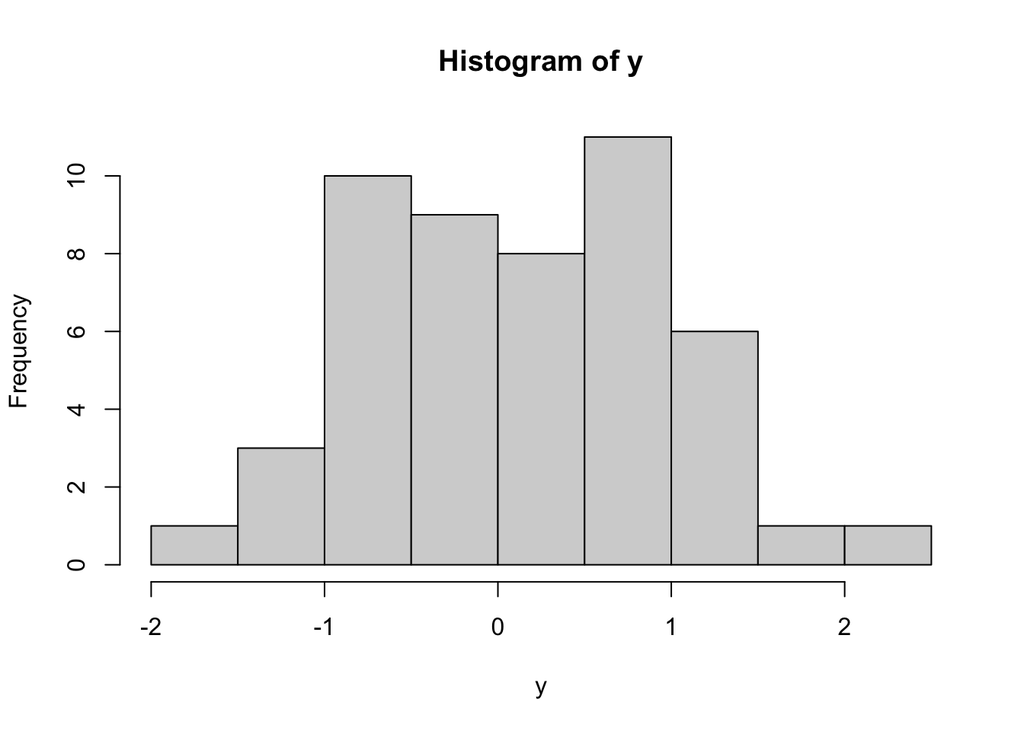

```r
# sample 50 numbers from the standard normal distribution
y = rnorm(50)

# look at the histogram - it's like the density function
hist(y)
```

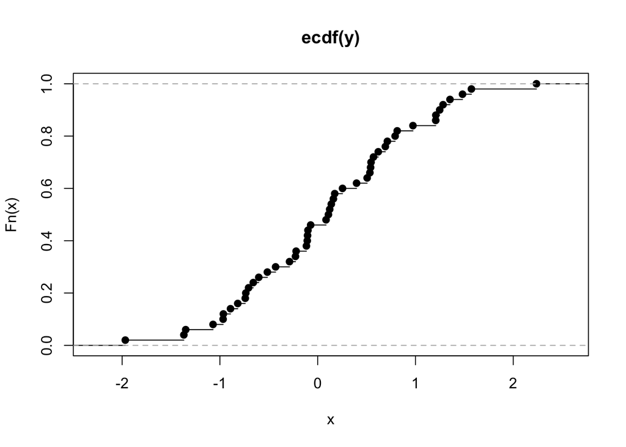

```r
# look at the empirical distribution function - it's like the distribution function
plot( ecdf(y) )
```

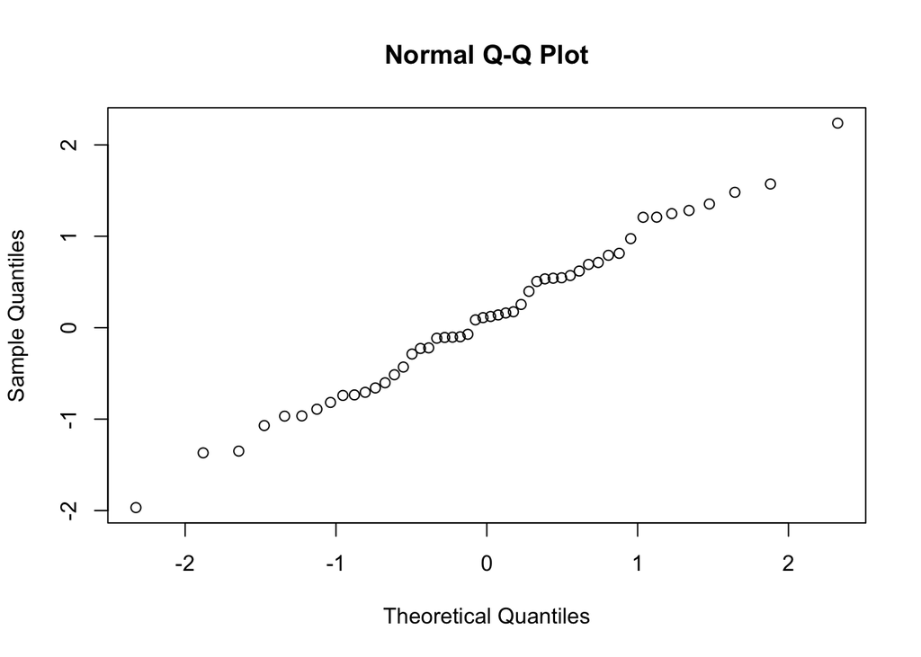

```r
# look at the QQ plot - it demonstrates how closely the distribution matches the quantiles of a Normal distribution.
qqnorm(y)
```

## Looking at real data

### Normal data: using the t-distribution

In the `fosdata` package there is a dataset called `mice_pot`, which contains data from an experiment where mice were dosed with THC and then measured for motor activity as a percentage of their baseline activity. We are going to look at the group that got a medium dose of THC.

```r
# import the fosdata package and the mice_pot data
library( 'fosdata' )
```

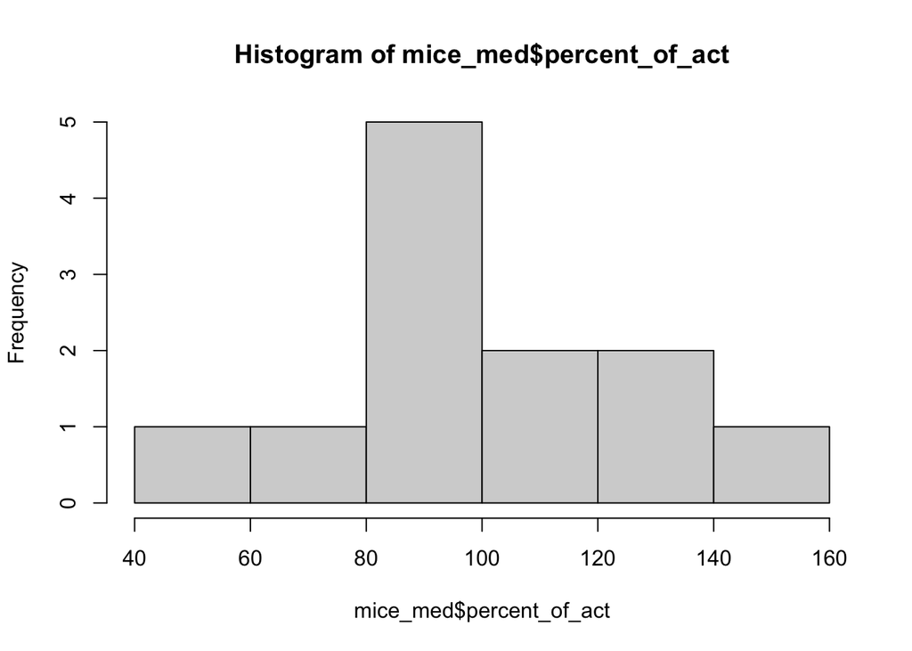

```r
data( mice_pot )

# extract just the mice that got the medium dose of THC
mice_med = mice_pot[ mice_pot$group == 1, ]

# look at the histogram and QQ plot to assess whether the data are approximately normal
hist( mice_med$percent_of_act )
```

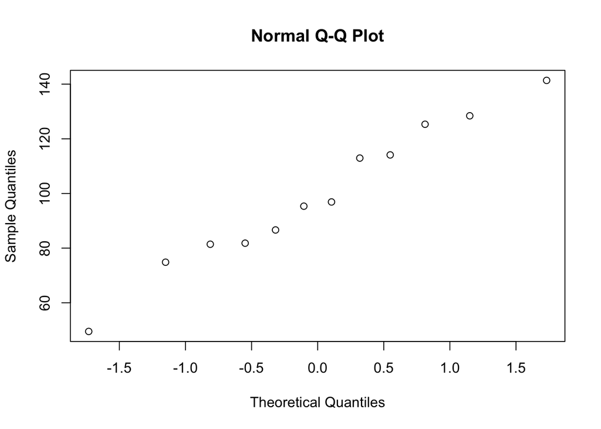

```r
qqnorm( mice_med$percent_of_act )
```

#### Find the 80% confidence interval for the population mean

Now we are using our sample to make some determination about the population, so this is statistical inference. Our best guess of the population mean is the sample mean, `mean( mice_med$percent_of_act )`, which is 99.1%. But to get a confidence interval, we need to use the formula
$$\bar{x} \pm t_{n-1, 0.1} * S / \sqrt{n}$$
Going piece-by-piece in this formula:

```r
# calculate the sample mean, sample standard deviation, and sample size:
x_bar = mean( mice_med$percent_of_act )
s = sd( mice_med$percent_of_act )
n = nrow( mice_med )

# calculate the relevant quantiles of the t-distribution.
# use the 0.1 and 0.9 quantiles because we want the 80% confidence interval
# and (1-0.8) / 2 = 0.1 and 1 - 0.1 = 0.9.
t_low = qt(0.1, df=n-1)
t_high = qt(0.9, df=n-1)

# calculate the confidence interval:
cat( "The 80% CI is (", x_bar + t_low * s / sqrt(n), ", ", x_bar + t_high * s / sqrt(n), ").")
```

```
## The 80% CI is ( 88.71757 ,  109.3871 ).
```

```r
# check your calculation with the t.test function:
t.test( mice_med$percent_of_act, conf.level=0.8 )
```

```
##
##  One Sample t-test
##
## data:  mice_med$percent_of_act
## t = 13.068, df = 11, p-value = 4.822e-08
## alternative hypothesis: true mean is not equal to 0
## 80 percent confidence interval:
##   88.71757 109.38712
## sample estimates:
## mean of x
##  99.05235
```

### Non-normal data: resampling

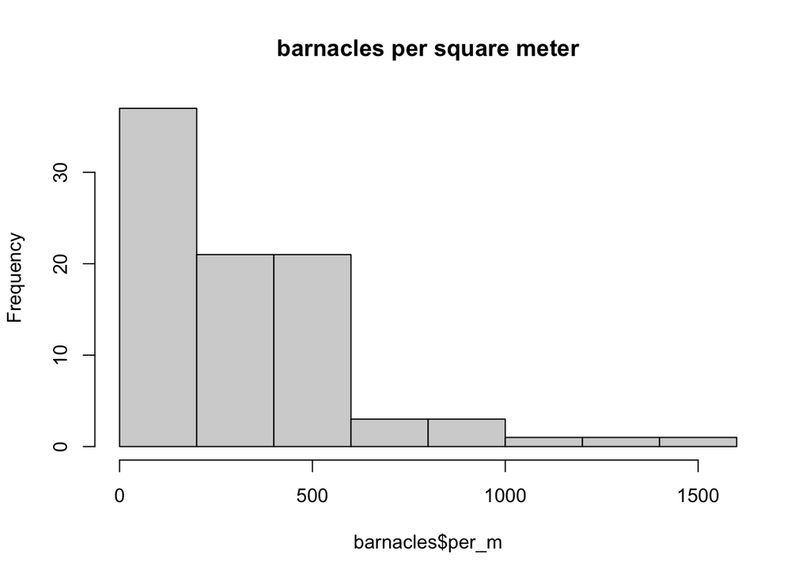

```r
# import the fosdata package and the barnacles data
library( 'fosdata' )
data( barnacles )

# calculate the number of barnacles per unit area for each sample:
barnacles$per_m = barnacles$count / barnacles$area_m

# examine the histogram and QQ plot of the barnacles per unit area:
hist( barnacles$per_m, main="barnacles per square meter" )
```

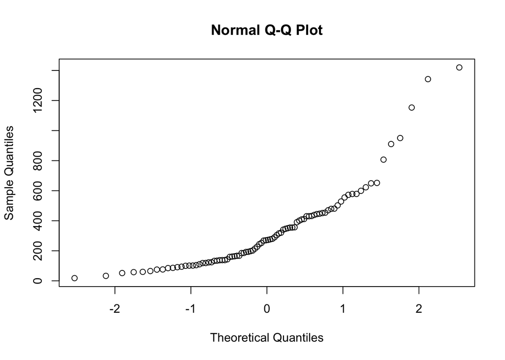

```r
qqnorm( barnacles$per_m )
```

```r
# does it look to you like the barnacles per unit area are distributed like a normal distribution?
```

We should conclude that the data are obviously non-normal.

#### Bootstrap-t distribution:

In this case, the observations themselves are not normally distributed so the t-distribution derived from the CLT will be only an approximation. But there is another option: resampling. This means shuffling our original data to generate new values of the t-statistic, and then working directly from this “bootstrap-t” distribution for inferences. Here is the procedure for generating your bootstrap-t distribution:

1. Compute the sample mean $\bar{x}$.
2. Repeat the following many times:
- Resample from the barnacle data with replacement, calling the resample `z`.
- Calculate the t-statistic (centered at $\bar{x}$) for this resample and call it `t_boot[[i]]`. The formula is `( mean(z) - mean(barnacles$per_m) ) / ( sd(z) / sqrt(n) )`.

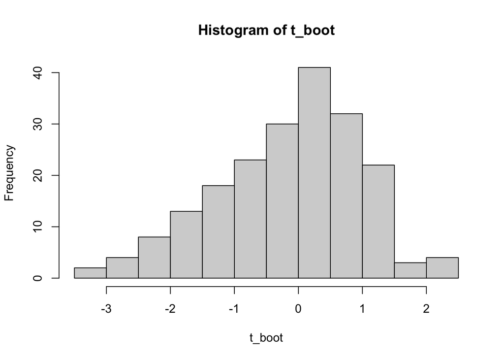

```r
# define the sample size and a
B = 200
t_boot = numeric( B )

for (i in 1:B) {
  z = sample( barnacles$per_m, replace=TRUE )
  t_boot[[i]] = ( mean(z) - mean(barnacles$per_m) ) / ( sd(z) / sqrt(length(z)) )
}

hist(t_boot)
```